# MEML_HW_02_Soln

**Machine Learning for Mechanical Engineering**  
**Homework 02: Solution**  
**Due Tuesday, 03/26/2019, 9:30 AM**

By Prof. Seungchul Lee  
http://iai.postech.ac.kr/  
Industrial AI Lab at POSTECH

- For your handwritten solution, hand in your hardcopy before the class begins.
- For your code, email your .ipynb file to iai.postech@gmail.com. Only .ipynb file will be graded.
- When you send an e-mail, write down [Machine Learning Homework] on the title
- And please write your NAME on your .ipynb files. ex) 이남정_20192319 _HW1.ipynb
- Do not submit a printed version of your code. It will not be graded.
- If you have any questions on the homework problems, please email our TA via yenamy96@gmail.com.

# Problem 1

Find solution $D$ of the optimization problem with the following objective function and constraints. Here, $\lVert \cdot \rVert_2$ is the Euclidean norm (or distance).

(Hint: you do not have to find the optimal value of $Z$)

$$\begin{align*} D= \min_Z \quad & \lVert X_1 - Z \rVert_2 + \lVert X_2 - Z \rVert_2 \\ \\ \text{subject to} \quad & Z \in V=\text{span} \{V_1, V_2\} \end{align*}$$

[figure not shown]

### Solution

$D^*$ is the shortest distance from $X_1$ to $X_2$ via $Z$ on the spanned hyperplane. The shortest line is the straight line from $X_1$ and $Y$ which is mirrored reflection of $X_2$ with respect to the hyperplane.

$$ \begin{align*} D^* &= \lVert X_1 - MX_2 \rVert = \lVert X_1 - \left( 2V \left(V^TV \right)^{-1}V^T-I\right)X_2\rVert \\ &=\lVert MX_1 - X_2\rVert \end{align*} $$

where $M$ is mirror transformation and $V = [V_1 \; V_2]$

[figure not shown]

# Problem 2

(a) Suppose $x_i$'s are features. It can be considered as feature $x_j$ is not important when

$$ P(y \mid x_1, \cdots x_{j-1}, x_j, x_{j+1}, \cdots x_N) = P(y \mid x_1, \cdots x_{j-1}, x_{j+1}, \cdots x_N).$$

Discuss why. Here, $P(\cdot \mid \cdot)$ is a conditional density probability.

(b) Load [lasso_input_data.pkl](https://www.dropbox.com/s/4ws06b7li283zks/lasso_input_data.pkl?dl=1) and [lasso_target_data.pkl](https://www.dropbox.com/s/taw1xkmgz5sg3tz/lasso_target_data.pkl?dl=1) using the followig command.

```python
from six.moves import cPickle
x = cPickle.load(open('./data_files/lasso_input_data.pkl', 'rb'))
y = cPickle.load(open('./data_files/lasso_target_data.pkl', 'rb'))

# x.shape
# y.shape
```

In this problem, you are asked to predict a target value from 13 features (input data). Assume that your model has the following relationship:

$$\omega_1 x_1 + \omega_2 x_2 + \cdots + \omega_{13} x_{13} = y$$

Build the linear regression model using Lasso regularizer.

(Hint : You can use cvxpy module to solve optimization problem)

```python
# Write your code here
```

(c) After applying Lasso, we can select meaningful features. Plot the magnitudes of all $\omega$'s and tell which features are important.

```python
# Write your code here
```

### Solution

(a)

Let's denote $\mathbf{x}_{-j}$ the vector $\mathbf{x}$ without the $j$-th element $x_j$. $ P(y \mid \mathbf{x}) = P(y \mid \mathbf{x}_{-j}) $ indicates $y$ is independent of $x_{j}$. Hence $x_j$ is not an important feature.

(b)

```python
import numpy as np
import matplotlib.pyplot as plt
from six.moves import cPickle

A = cPickle.load(open('./data_files/lasso_input_data.pkl', 'rb'))
y = cPickle.load(open('./data_files/lasso_target_data.pkl', 'rb'))
```

```python
y.shape
```

```
(506,)
```

```python
# Write your code here
import cvxpy as cvx

y = y.reshape(506,1)
d = 13

lamb = 20
theta = cvx.Variable([d, 1])
obj = cvx.Minimize(cvx.sum_squares(A*theta - y) + lamb*cvx.norm(theta, 1))
prob = cvx.Problem(obj, [])
result = prob.solve()
print(theta.value)
```

```
[[-9.04561743e-02]
 [ 4.91009865e-02]
 [-1.60284532e-02]
 [ 2.50258958e+00]
 [-1.10389334e-04]
 [ 5.76795168e+00]
 [-9.18045089e-03]
 [-9.35522567e-01]
 [ 1.72000554e-01]
 [-1.00204504e-02]
 [-3.89153597e-01]
 [ 1.48190016e-02]
 [-4.32917453e-01]]
```

(c)

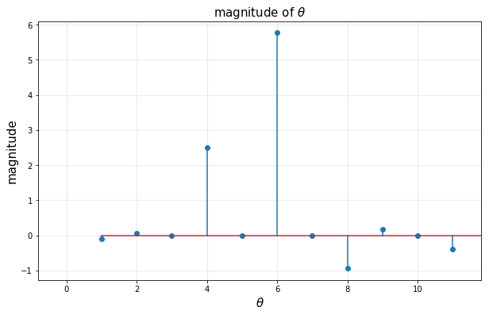

```python
# Regulization (= lasso nonlinear regression) encourages zero weights
plt.figure(figsize = (10, 6))
plt.title(r'magnitude of $\theta$', fontsize = 15)
plt.xlabel(r'$\theta$', fontsize = 15)
plt.ylabel('magnitude', fontsize = 15)
plt.stem(np.linspace(1, 13, 13).reshape(-1, 1), theta.value)
plt.axis('equal')
plt.xlim([0.5, 10.5])
plt.grid(alpha = 0.3)
plt.show()
```

# Problem 3

Suppose you receive the binary signal. The signal is corrupted with noises while transmitting through channels. We want to estimate noise from the original signal through the $L_1$ optimization. The mathematical problem statement is given:

$$ \begin{array}{Icr}\begin{align*} y = x + \omega\\ x \in \{ 0, 1 \}\\ \omega \text{ is noise} \end{align*}\end{array} \quad \Longrightarrow \begin{array}{I} \quad \text{Recover original signal } x \text{ from corrupted signal } y \end{array} $$

### Step 1. Data generation

(a) First, generate the original signal of 200 data points as shown in the below figure. This can be simply done using ones and zeros commands in Python.

[figure not shown]

```python
# Write your code here
```

(b) Next, corrupt the original signal with Gaussian noise. This can be done using randn command in Python. One of realizations of the corrupted signal will be given:

[figure not shown]

```python
# Write your code here
```

### Step 2. $L_1$ optimization

Note that the signal is sparse (in a sense of frequency domain). Therefore we can apply the $L_1$ optimization. We will optimize the $L_1$ loss function with the $L_2$ constraints.

(c) Plot the reconstructed signal. In addition, by changing the beta, explain how beta affects in an optimization process. One of reconstructed signal with a proper value of beta is shown below:

[figure not shown]

```python
# Write your code here
```

## Step 1. Data generation

```python
x.shape
```

[output not shown]

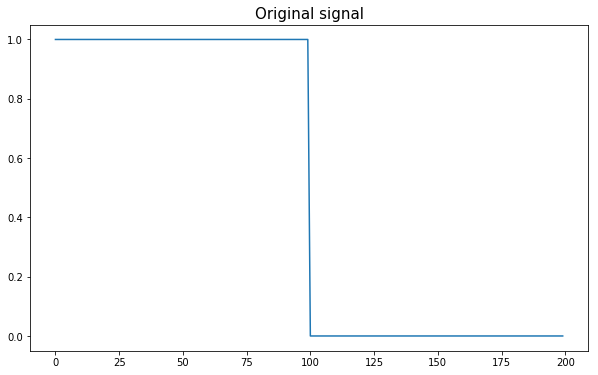

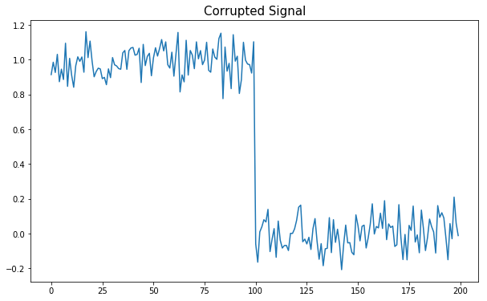

```python
import numpy as np
import cvxpy as cvx
import matplotlib.pyplot as plt
%matplotlib inline

ones = np.ones([100,1])
zeros = np.zeros([100, 1])

x = np.vstack([ones, zeros])
x_cor = x + 0.1*np.random.randn(200, 1)

plt.figure(figsize = (10, 6))
plt.plot(x)
plt.title('Original signal', fontsize=15)
plt.show()

plt.figure(figsize = (10, 6))
plt.plot(x_cor)
plt.title('Corrupted Signal', fontsize=15)
plt.show()
```

## Step 2. $L_1$ optimization

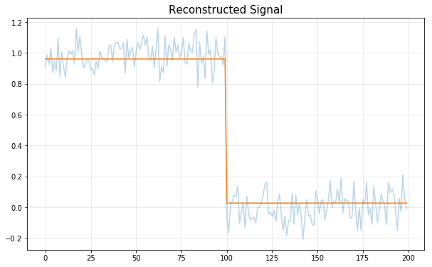

```python
# Step 2
beta = 1.3
x_hat = cvx.Variable([200, 1])
obj = cvx.Minimize(cvx.norm(x_hat[1:200] - x_hat[0:199], 1))
const = [cvx.norm(x_hat - x_cor, 2) <= beta]
prob = cvx.Problem(obj, const)
result = prob.solve()

x_hat = np.asarray(x_hat.value)

plt.figure(figsize = (10, 6))
plt.plot(x_cor, alpha = 0.3)
plt.plot(x_hat)
plt.title('Reconstructed Signal', fontsize=15)
plt.grid(alpha = 0.3)
plt.show()
```